# Green Book Section I.C.1.a — Flagged parcels

### Taboose-Aberdeen — Parcel TIN064

**Support** = *decline evidence only* (cover↓ / grass↓ / shrub↑ vs baseline; sustained counters and percentile rows on the same sign gate). **Not supported** = type-stable / contrary signals (grass↑ / shrub↓ / cover↑; high grass / still-Type-C proportions; DTW & NDVI context). Not attributability or cause (see I.C.1.b).

Support (decline evidence)

#### Change vs baseline

|  | current | baseline | Δ |
| --- | --- | --- | --- |
| Grass | 8.1% | 20.7% | -12.6 pp |
| Shrub | 24.2% | 10.0% | +14.2 pp |

#### Sustained counters

Grass29 years below baselineI.C.1.a sustained-change screen

#### Percentile rank

|  | current | baseline | Δ |
| --- | --- | --- | --- |
| Grass | 80 | 100 | -20 pct pts |
| Shrub | 87 | 3 | +83 pct pts |

Not supported (type-stable / contrary)

#### Change vs baseline

|  | current | baseline | Δ |
| --- | --- | --- | --- |
| Cover | 32.4% | 31.3% | +1.1 pp |

#### Sustained counters

Cover0 years below baseline

#### Percentile rank

|  | current | baseline | Δ |
| --- | --- | --- | --- |
| Cover | 83 | 80 | +3 pct pts |

#### Perennial proportions (type-stable)

Grass30% of perennial cover

Shrub70% of perennial cover

#### Hydrologic context

DTW (ft BGS)current 13.3baseline 22.2Δ -8.9 ft (shallower)

#### NDVI vegetation index

| Period | NDVI |
| --- | --- |
| Most recent (2026) | 0.266 |
| Baseline (1986) | 0.267 |
| Δ (recent − baseline) | -0.001 |

Baseline Cover residual vs NDVI–cover fit: +2.1 pp (placeholder screen ±15 pp).

[Jul 15–Sep 15 aggregate; roughly two months after the June–late-July LPT sampling window.]

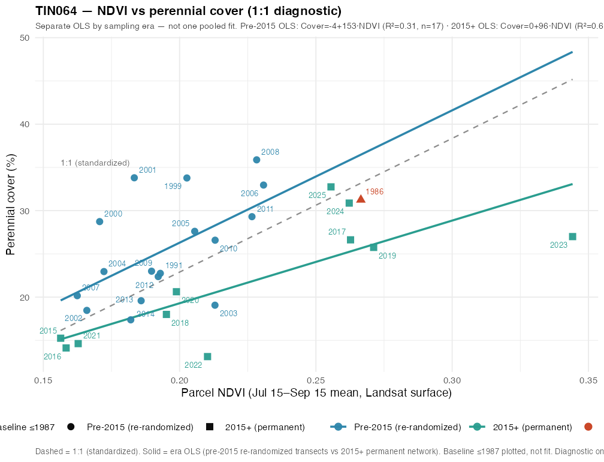

NDVI↔︎cover 1:1 diagnostic with separate OLS for pre-2015 (re-randomized) vs 2015+ (permanent); dashed = standardized 1:1. Unexpected baseline offset → investigate baseline validity.

Next steps

- Depth-to-water (DTW) is currently shallower than the 1986 baseline measurement on this parcel. In plain terms, the water table is closer to the surface than it was at the 1986 baseline measurement. The Green Book “adequacy-for-type” hydro screen asks whether depth is too deep for the mapped vegetation type; a shallower reading does not, by itself, push that screen. It also does not prove or disprove pumping as a cause — it only means hydrology alone is not the red flag here. Still check composition change, baseline quality (including NDVI↔︎cover residuals), and other I.C.1.b factors before causal language.

Type-stable notes (also under Not supported)

- Shrub share below the Type C→B ≥80% reference — high-shrub alarm does not apply at present.

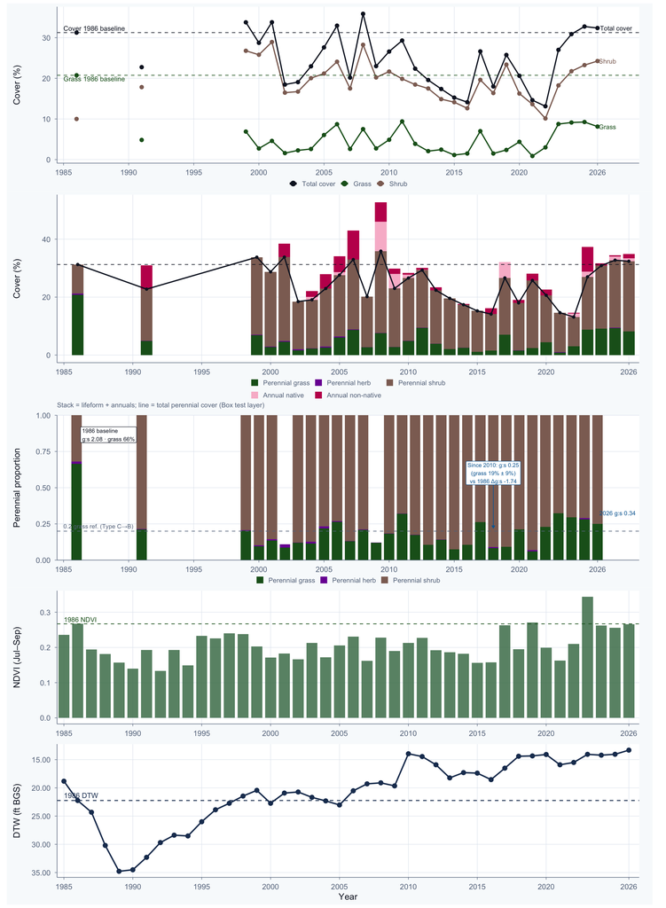

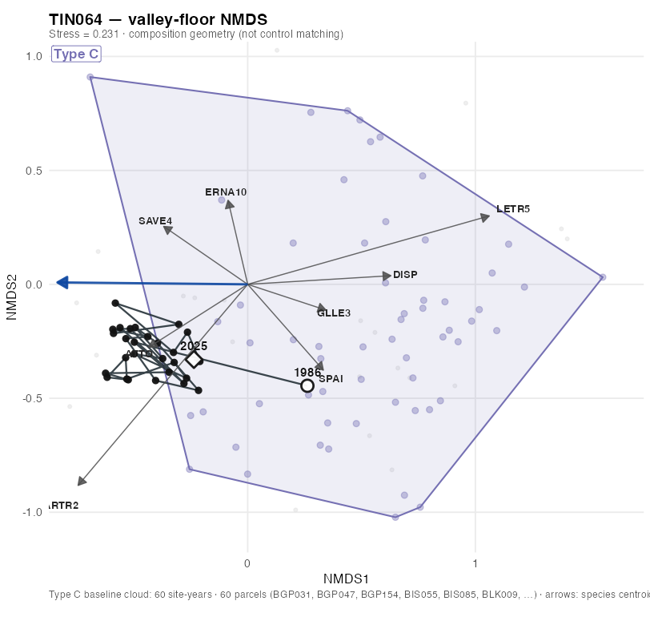

**NMDS path** — valley-floor composition geometry; Type callout = mapped GB type; caption lists same-TYPE cloud n (site-years / parcels); arrows = dominant species centroids + DTW gradient (not control matching).

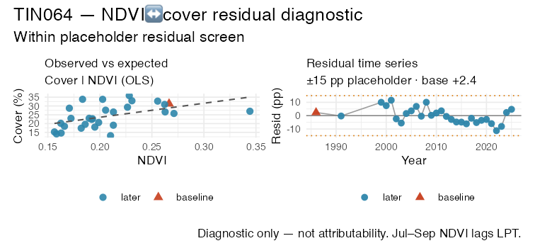

**NDVI residual** — observed vs expected Cover|NDVI and residual time series; unexpected baseline offset → investigate baseline validity.

### Thibaut Sawmill — Parcel IND026

#### Topographic context + photo

Parcel-framed hillshade (2022 Sierra (CA_FEMAR9Southeast)) with boundary, adjoining parcels, All_2026 transect starts (n=16), and representative photo point. Measurability / landscape context only — not attributability.

*Requested 300 m adjoining-context pad; clipped to ind026_ind029_2022 DTM extract extent (W/N limited by extract).*

**LiDAR map** — hillshade + optional CHM / height / SAM layers (Layers / Expand)

### Layers

Rasters

Hillshade0.5 m Sierra 2022

CHM height strata1<0.5 · 2 0.5–1.5 · 3 1.5–3 · 4 >3 m

Small-shrub0.3–3 m (BWMA liberal_v1)

Tree>3 m

Vectors

Parcel boundary

Adjoining parcels

Transect startsAll_2026

Photo point

SAM outlinesn=495 · research

SAM labeledn=12 · LPT lifeform

Yellow parcel · Cyan adjoining · Red starts · Orange photo · CHM strata / small-shrub 0.3–3 m / tree >3 m (layer panel) · SAM outlines · SAM labeled (optional toggles)

**Research overlay** — NAIP 2022 SAM segments × LPT 2022 lifeform labels. Not vegetation TYPE · not I.C.1.b attributability. Use the layer panel to toggle SAM / CHM / height bins.

Residual gap closed — 16/16 LPT starts in sam_amg; 12 labeled AMG segments (Eco denser-v2). Popups show shrub_abs + top gated species (SPAI / ARTR2 / ATTO / ERNA10).

[figure not shown]

**IND026_05_212** · 2024-07-02 (AGOL / LPT start-point attachment)

#### Decade species-rank comparison

**Earliest top-10 reorder vs baseline:** 2005 (first dated order difference on this parcel).

**Note:** No LPT visits for 1990s — column omitted. Research framing (decade perennial relative ranks); not I.C.1.b.

| Species | Baseline (1985) | 2000s | 2010s | 2026 |
| --- | --- | --- | --- | --- |
| **SPAI** Sporobolus airoides Grass | 1 sacaton, Alkali 49.00% (1.000) | 4 sacaton, Alkali 1.87% (0.065) | 4 sacaton, Alkali 2.74% (0.068) | 4 sacaton, Alkali 3.56% (0.095) |
| **ATTO** Atriplex torreyi Shrub | — | 1 saltbush, Nevada/Torrey’s 16.42% (0.522) | 1 saltbush, Nevada/Torrey’s 14.57% (0.358) | 2 saltbush, Nevada/Torrey’s 10.06% (0.268) |
| **ARTR2** Artemisia tridentata Shrub | — | 2 sagebrush, Big 6.04% (0.199) | 2 sagebrush, Big 11.14% (0.273) | 1 sagebrush, Big 17.12% (0.456) |
| **ERNA10** Ericameria nauseosa Shrub | — | 3 rabbitbrush, Common 2.05% (0.067) | 3 rabbitbrush, Common 3.31% (0.082) | 3 rabbitbrush, Common 4.31% (0.115) |
| **ATPO** Atriplex polycarpa Shrub | — | 5 saltbush, Allscale 1.18% (0.035) | 5 saltbush, Allscale 2.24% (0.054) | 5 saltbush, Allscale 1.00% (0.027) |

Rank by perennial relative cover within period (mean of visits present). Absolute = parcelMeanCover (%). Pre-2015 vs permanent-network (~2015+) sampling design can change transect counts — do not over-call design change as ecology.

**Support** = *decline evidence only* (cover↓ / grass↓ / shrub↑ vs baseline; sustained counters and percentile rows on the same sign gate). **Not supported** = type-stable / contrary signals (grass↑ / shrub↓ / cover↑; high grass / still-Type-C proportions; DTW & NDVI context). Not attributability or cause (see I.C.1.b).

Support (decline evidence)

#### Change vs baseline

|  | current | baseline | Δ |
| --- | --- | --- | --- |
| Cover | 37.6% | 49.0% | -11.4 pp |
| Grass | 3.9% | 49.0% | -45.1 pp |
| Shrub | 33.1% | 0.0% | +33.1 pp |

#### Sustained counters

Cover22 years below baselineI.C.1.a sustained-change screen

Grass22 years below baselineI.C.1.a sustained-change screen

#### Percentile rank

|  | current | baseline | Δ |
| --- | --- | --- | --- |
| Cover | 83 | 100 | -17 pct pts |
| Grass | 74 | 100 | -26 pct pts |
| Shrub | 87 | 4 | +83 pct pts |

#### Perennial proportions (type drift)

Grass10% of perennial cover

Shrub90% of perennial cover

Not supported (type-stable / contrary)

#### NDVI vegetation index

| Period | NDVI |
| --- | --- |
| Most recent (2026) | 0.277 |
| Baseline (1985) | 0.402 |
| Δ (recent − baseline) | -0.125 |

Baseline Cover residual vs NDVI–cover fit: +4.2 pp (placeholder screen ±15 pp).

[Jul 15–Sep 15 aggregate; roughly two months after the June–late-July LPT sampling window.]

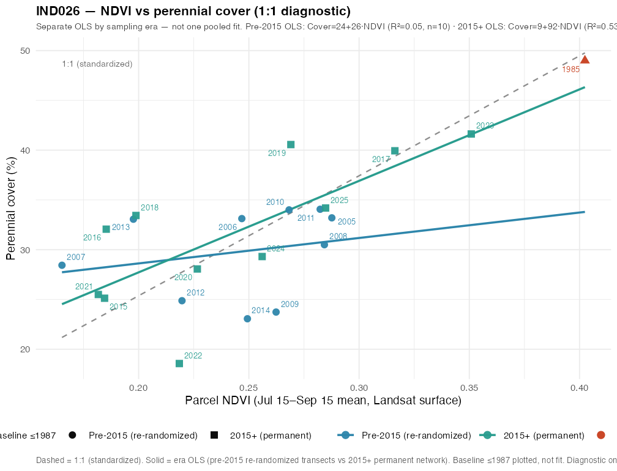

NDVI↔︎cover 1:1 diagnostic with separate OLS for pre-2015 (re-randomized) vs 2015+ (permanent); dashed = standardized 1:1. Unexpected baseline offset → investigate baseline validity.

Next steps

- Depth-to-water (DTW) is currently deeper than the 1985 baseline measurement (water table farther below ground). If that deeper condition is sustained and looks incompatible with mapped Type C, prioritize I.C.1.b water-table / soil-water factors in attributability analysis — together with rainfall, land use, and other stressors. Deeper DTW is context for causation review, not a final “but for” finding by itself.
- Measurability under Box I.C.1.a.ii is already established for this parcel (sustained cover and/or grass below baseline). Causation is a separate step: I.C.1.b attributability requires control comparisons, rainfall, land use, and other stressors before any “but for pumping / surface-water practice” conclusion.

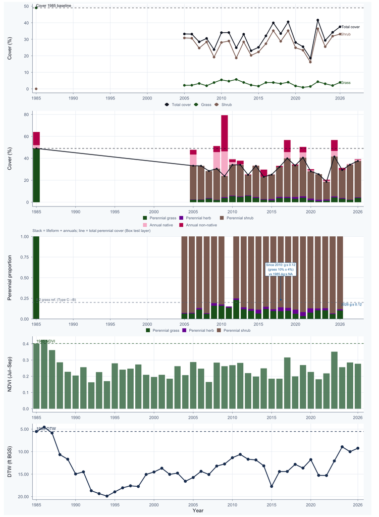

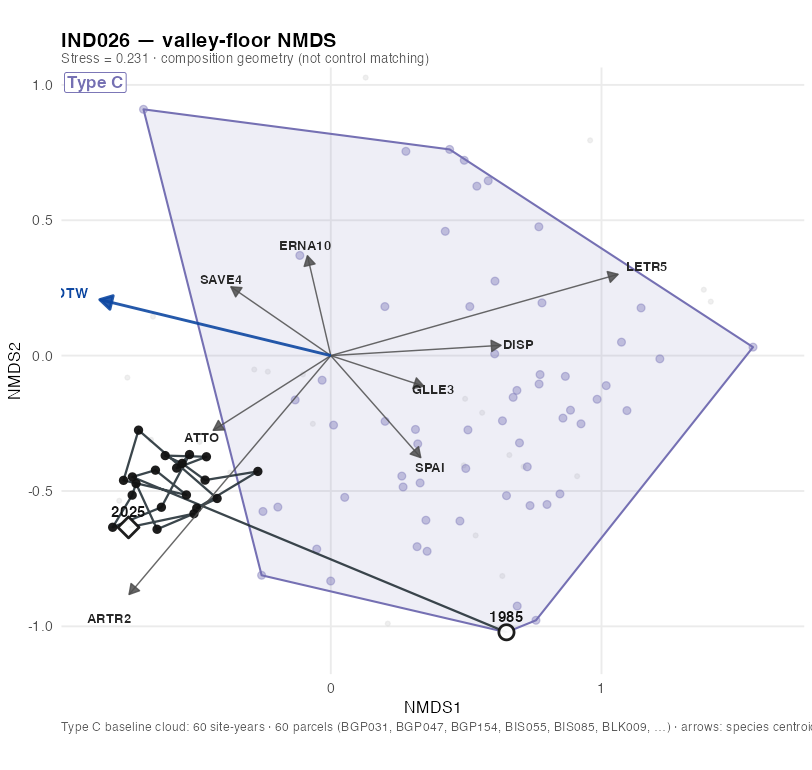

**NMDS path** — valley-floor composition geometry; Type callout = mapped GB type; caption lists same-TYPE cloud n (site-years / parcels); arrows = dominant species centroids + DTW gradient (not control matching).

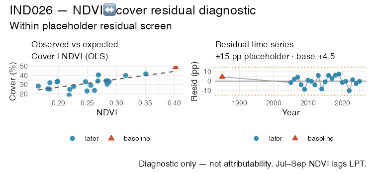

**NDVI residual** — observed vs expected Cover|NDVI and residual time series; unexpected baseline offset → investigate baseline validity.

### Thibaut Sawmill — Parcel IND029

**Support** = *decline evidence only* (cover↓ / grass↓ / shrub↑ vs baseline; sustained counters and percentile rows on the same sign gate). **Not supported** = type-stable / contrary signals (grass↑ / shrub↓ / cover↑; high grass / still-Type-C proportions; DTW & NDVI context). Not attributability or cause (see I.C.1.b).

Support (decline evidence)

#### Change vs baseline

|  | current | baseline | Δ |
| --- | --- | --- | --- |
| Grass | 1.1% | 14.0% | -12.9 pp |
| Shrub | 23.5% | 8.0% | +15.5 pp |

#### Sustained counters

Grass26 years below baselineI.C.1.a sustained-change screen

#### Percentile rank

|  | current | baseline | Δ |
| --- | --- | --- | --- |
| Grass | 52 | 100 | -48 pct pts |
| Shrub | 44 | 4 | +41 pct pts |

#### Perennial proportions (type drift)

Grass0% of perennial cover

Shrub90% of perennial cover

Not supported (type-stable / contrary)

#### Change vs baseline

|  | current | baseline | Δ |
| --- | --- | --- | --- |
| Cover | 25.6% | 22.0% | +3.6 pp |

#### Sustained counters

Cover0 years below baseline

#### Percentile rank

|  | current | baseline | Δ |
| --- | --- | --- | --- |
| Cover | 44 | 19 | +26 pct pts |

#### Hydrologic context

DTW (ft BGS)current 10.4baseline 4.9Δ +5.5 ft (deeper)

#### NDVI vegetation index

| Period | NDVI |
| --- | --- |
| Most recent (2026) | 0.216 |
| Baseline (1985) | 0.236 |
| Δ (recent − baseline) | -0.020 |

Baseline Cover residual vs NDVI–cover fit: -9.6 pp (placeholder screen ±15 pp).

[Jul 15–Sep 15 aggregate; roughly two months after the June–late-July LPT sampling window.]

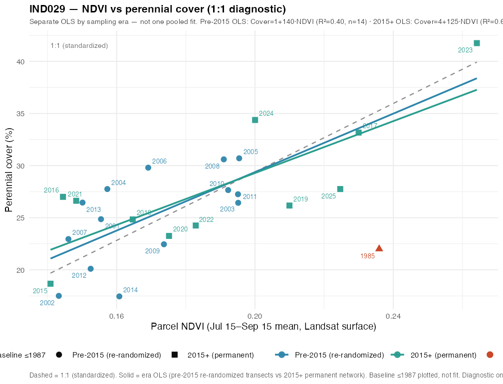

NDVI↔︎cover 1:1 diagnostic with separate OLS for pre-2015 (re-randomized) vs 2015+ (permanent); dashed = standardized 1:1. Unexpected baseline offset → investigate baseline validity.

Next steps

- Depth-to-water (DTW) is currently deeper than the 1985 baseline measurement (water table farther below ground). If that deeper condition is sustained and looks incompatible with mapped Type C, prioritize I.C.1.b water-table / soil-water factors in attributability analysis — together with rainfall, land use, and other stressors. Deeper DTW is context for causation review, not a final “but for” finding by itself.

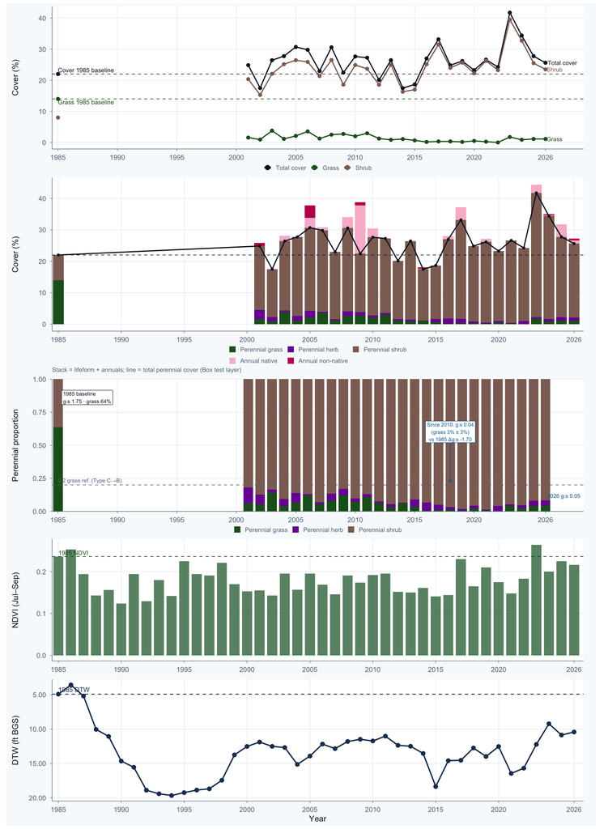

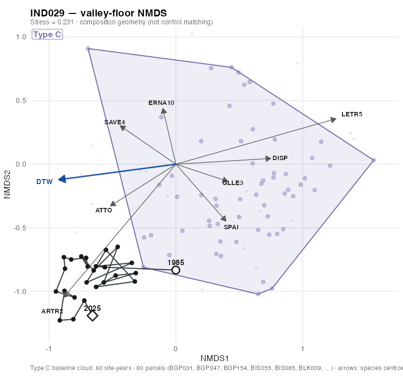

**NMDS path** — valley-floor composition geometry; Type callout = mapped GB type; caption lists same-TYPE cloud n (site-years / parcels); arrows = dominant species centroids + DTW gradient (not control matching).

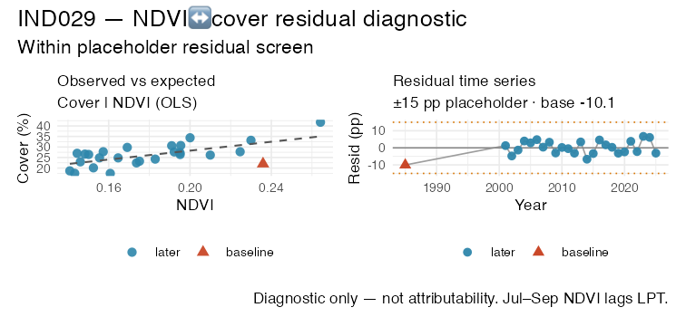

**NDVI residual** — observed vs expected Cover|NDVI and residual time series; unexpected baseline offset → investigate baseline validity.

### Independence Oak — Parcel IND021

**Support** = *decline evidence only* (cover↓ / grass↓ / shrub↑ vs baseline; sustained counters and percentile rows on the same sign gate). **Not supported** = type-stable / contrary signals (grass↑ / shrub↓ / cover↑; high grass / still-Type-C proportions; DTW & NDVI context). Not attributability or cause (see I.C.1.b).

Support (decline evidence)

#### Change vs baseline

|  | current | baseline | Δ |
| --- | --- | --- | --- |
| Cover | 42.6% | 68.0% | -25.4 pp |
| Grass | 13.6% | 28.0% | -14.4 pp |

#### Sustained counters

Cover15 years below baselineI.C.1.a sustained-change screen

Grass13 years below baselineI.C.1.a sustained-change screen

#### Percentile rank

|  | current | baseline | Δ |
| --- | --- | --- | --- |
| Cover | 39 | 100 | -61 pct pts |
| Grass | 56 | 94 | -39 pct pts |

Not supported (type-stable / contrary)

#### Change vs baseline

|  | current | baseline | Δ |
| --- | --- | --- | --- |
| Shrub | 24.0% | 39.0% | -15.0 pp |

#### Percentile rank

|  | current | baseline | Δ |
| --- | --- | --- | --- |
| Shrub | 28 | 94 | -67 pct pts |

#### Perennial proportions (type-stable)

Grass30% of perennial cover

Shrub60% of perennial cover

#### Hydrologic context

DTW (ft BGS)current 1.8baseline 3.4Δ -1.6 ft (shallower)

#### NDVI vegetation index

| Period | NDVI |
| --- | --- |
| Most recent (2026) | 0.383 |
| Baseline (1985) | 0.506 |
| Δ (recent − baseline) | -0.123 |

Baseline Cover residual vs NDVI–cover fit: +9.3 pp (placeholder screen ±15 pp).

[Jul 15–Sep 15 aggregate; roughly two months after the June–late-July LPT sampling window.]

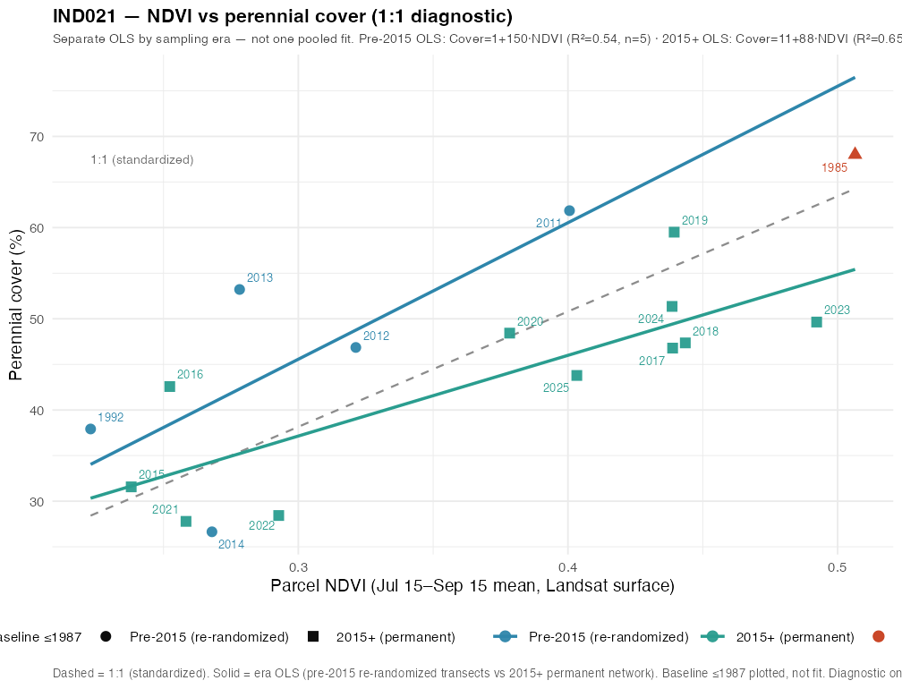

NDVI↔︎cover 1:1 diagnostic with separate OLS for pre-2015 (re-randomized) vs 2015+ (permanent); dashed = standardized 1:1. Unexpected baseline offset → investigate baseline validity.

Next steps

- Depth-to-water (DTW) is currently shallower than the 1985 baseline measurement on this parcel. In plain terms, the water table is closer to the surface than it was at the 1985 baseline measurement. The Green Book “adequacy-for-type” hydro screen asks whether depth is too deep for the mapped vegetation type; a shallower reading does not, by itself, push that screen. It also does not prove or disprove pumping as a cause — it only means hydrology alone is not the red flag here. Still check composition change, baseline quality (including NDVI↔︎cover residuals), and other I.C.1.b factors before causal language.
- Measurability under Box I.C.1.a.ii is already established for this parcel (sustained cover and/or grass below baseline). Causation is a separate step: I.C.1.b attributability requires control comparisons, rainfall, land use, and other stressors before any “but for pumping / surface-water practice” conclusion.

Type-stable notes (also under Not supported)

- Shrub share below the Type C→B ≥80% reference — high-shrub alarm does not apply at present.

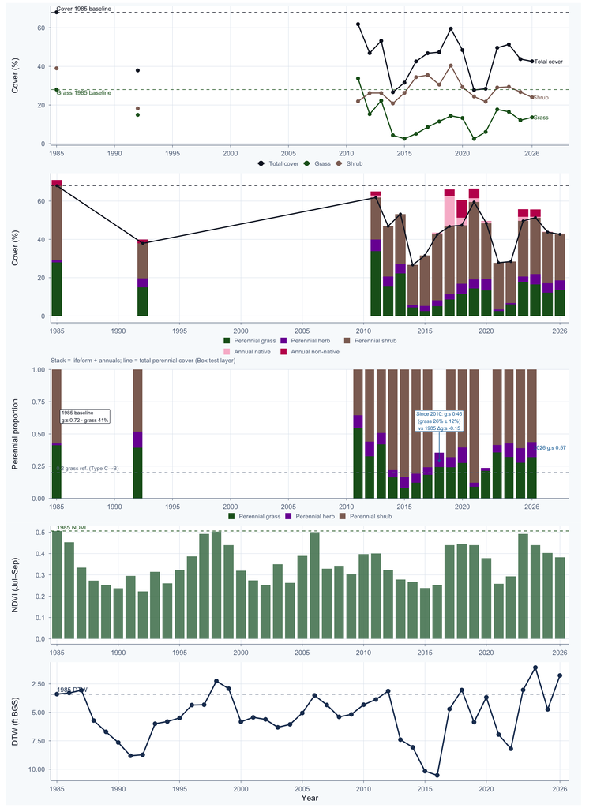

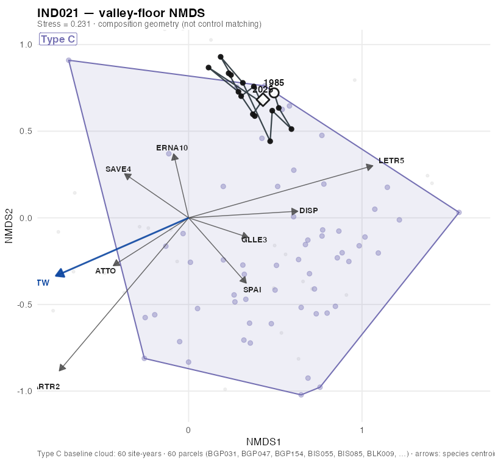

**NMDS path** — valley-floor composition geometry; Type callout = mapped GB type; caption lists same-TYPE cloud n (site-years / parcels); arrows = dominant species centroids + DTW gradient (not control matching).

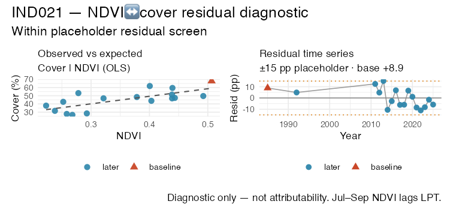

**NDVI residual** — observed vs expected Cover|NDVI and residual time series; unexpected baseline offset → investigate baseline validity.

### Symmes Shepherd — Parcel IND139

**Support** = *decline evidence only* (cover↓ / grass↓ / shrub↑ vs baseline; sustained counters and percentile rows on the same sign gate). **Not supported** = type-stable / contrary signals (grass↑ / shrub↓ / cover↑; high grass / still-Type-C proportions; DTW & NDVI context). Not attributability or cause (see I.C.1.b).

Support (decline evidence)

#### Change vs baseline

|  | current | baseline | Δ |
| --- | --- | --- | --- |
| Cover | 39.3% | 48.5% | -9.2 pp |
| Grass | 8.2% | 18.0% | -9.8 pp |

#### Sustained counters

Grass36 years below baselineI.C.1.a sustained-change screen

#### Percentile rank

|  | current | baseline | Δ |
| --- | --- | --- | --- |
| Cover | 70 | 100 | -30 pct pts |
| Grass | 78 | 100 | -22 pct pts |

Not supported (type-stable / contrary)

#### Change vs baseline

|  | current | baseline | Δ |
| --- | --- | --- | --- |
| Shrub | 29.6% | 30.5% | -0.9 pp |

#### Percentile rank

|  | current | baseline | Δ |
| --- | --- | --- | --- |
| Shrub | 70 | 81 | -11 pct pts |

#### Perennial proportions (type-stable)

Grass20% of perennial cover

Shrub80% of perennial cover

#### Hydrologic context

DTW (ft BGS)current 11.9baseline 7.6Δ +4.2 ft (deeper)

#### NDVI vegetation index

| Period | NDVI |
| --- | --- |
| Most recent (2026) | 0.242 |
| Baseline (1985) | 0.297 |
| Δ (recent − baseline) | -0.056 |

Baseline Cover residual vs NDVI–cover fit: -1.0 pp (placeholder screen ±15 pp).

[Jul 15–Sep 15 aggregate; roughly two months after the June–late-July LPT sampling window.]

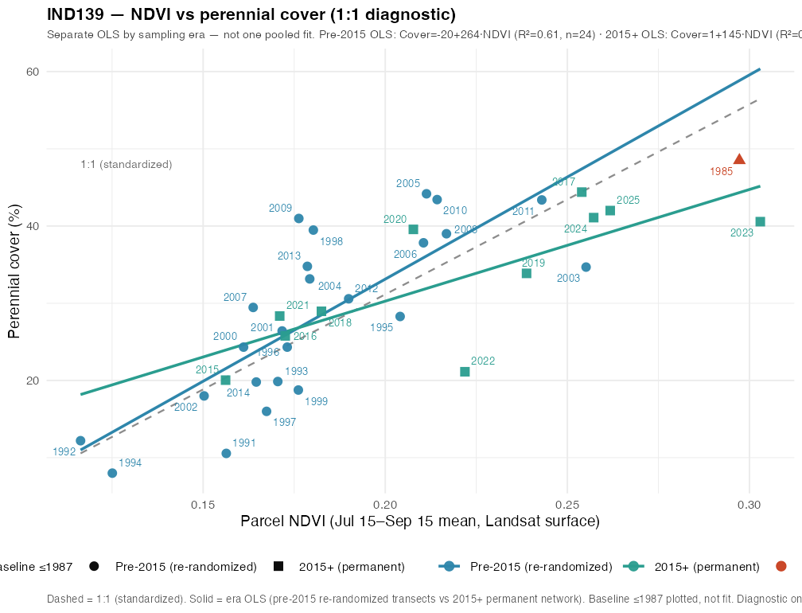

NDVI↔︎cover 1:1 diagnostic with separate OLS for pre-2015 (re-randomized) vs 2015+ (permanent); dashed = standardized 1:1. Unexpected baseline offset → investigate baseline validity.

Next steps

- Depth-to-water (DTW) is currently deeper than the 1985 baseline measurement (water table farther below ground). If that deeper condition is sustained and looks incompatible with mapped Type C, prioritize I.C.1.b water-table / soil-water factors in attributability analysis — together with rainfall, land use, and other stressors. Deeper DTW is context for causation review, not a final “but for” finding by itself.

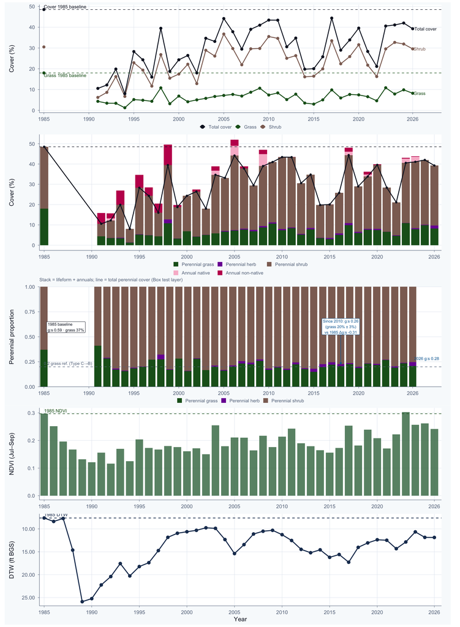

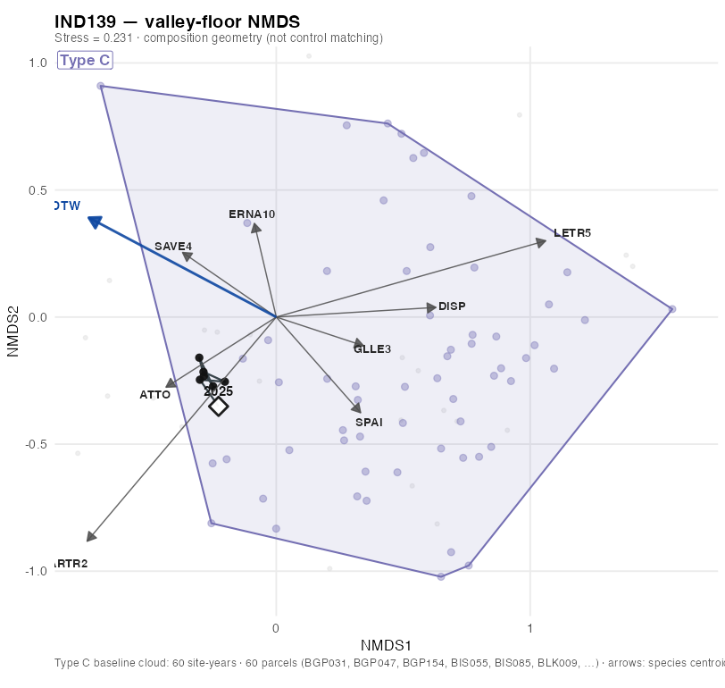

**NMDS path** — valley-floor composition geometry; Type callout = mapped GB type; caption lists same-TYPE cloud n (site-years / parcels); arrows = dominant species centroids + DTW gradient (not control matching).

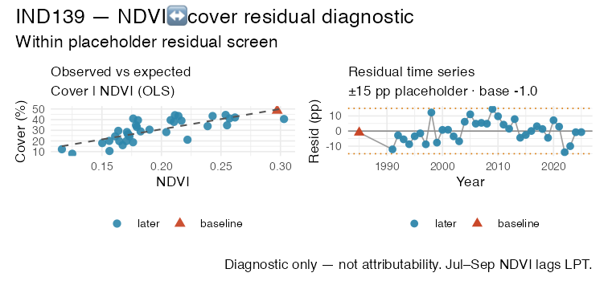

**NDVI residual** — observed vs expected Cover|NDVI and residual time series; unexpected baseline offset → investigate baseline validity.